# Machine Learning Project

Angel Ault

November 20, 2017

## Project Summary:

Using devices such as Jawbone Up, Nike FuelBand, and Fitbit, it is now possible to collect a large amount of data about personal activity relatively inexpensively. These devices contain sensors that are capable of recording raw biometric data to monitor three-dimensional movement or positioning with a high precision and accuracy.

For this study, we will use biometric data to predict what type of exercise the subject is doing. We will apply machine learning algorithms to train our model based on biometric data collected from six subjects as they performed five different types of exercise. These exercises are defined in the dataset under the field **classe**

Our model will be cross-validated to determine it’s accuracy, kappa score, confidence level, and confidence interval. Lastly, we will apply the model to predict 20 different test cases.

### Setup

Download the data from its web repository.

```r
#The source data URLs
trainingURL <- 'https://d396qusza40orc.cloudfront.net/predmachlearn/pml-training.csv'
testingURL <- 'https://d396qusza40orc.cloudfront.net/predmachlearn/pml-testing.csv'
#download the data top a local folder
download.file(url=trainingURL, destfile = 'pml-training.csv')
download.file(url=testingURL, destfile = 'pml-testing.csv')
```

Load the datasets.

```r
#load the training dataset
trainingData <- read.csv('pml-training.csv')
#load the validation data we will use to predict classe
validation <- read.csv('pml-testing.csv')
str(trainingData)
```

```
## 'data.frame':    19622 obs. of  160 variables:
##  $ X                       : int  1 2 3 4 5 6 7 8 9 10 ...
##  $ user_name               : Factor w/ 6 levels "adelmo","carlitos",..: 2 2 2 2 2 2 2 2 2 2 ...
##  $ raw_timestamp_part_1    : int  1323084231 1323084231 1323084231 1323084232 1323084232 1323084232 1323084232 1323084232 1323084232 1323084232 ...
##  $ raw_timestamp_part_2    : int  788290 808298 820366 120339 196328 304277 368296 440390 484323 484434 ...
##  $ cvtd_timestamp          : Factor w/ 20 levels "02/12/2011 13:32",..: 9 9 9 9 9 9 9 9 9 9 ...
##  $ new_window              : Factor w/ 2 levels "no","yes": 1 1 1 1 1 1 1 1 1 1 ...
##  $ num_window              : int  11 11 11 12 12 12 12 12 12 12 ...
##  $ roll_belt               : num  1.41 1.41 1.42 1.48 1.48 1.45 1.42 1.42 1.43 1.45 ...
##  $ pitch_belt              : num  8.07 8.07 8.07 8.05 8.07 8.06 8.09 8.13 8.16 8.17 ...
##  $ yaw_belt                : num  -94.4 -94.4 -94.4 -94.4 -94.4 -94.4 -94.4 -94.4 -94.4 -94.4 ...
##  $ total_accel_belt        : int  3 3 3 3 3 3 3 3 3 3 ...
##  $ kurtosis_roll_belt      : Factor w/ 397 levels "","-0.016850",..: 1 1 1 1 1 1 1 1 1 1 ...
##  $ kurtosis_picth_belt     : Factor w/ 317 levels "","-0.021887",..: 1 1 1 1 1 1 1 1 1 1 ...
##  $ kurtosis_yaw_belt       : Factor w/ 2 levels "","#DIV/0!": 1 1 1 1 1 1 1 1 1 1 ...
```

[output cut: 86 more lines]

### Data Cleanup

Our data contains a lot of NA values. Let’s remove them.

```r
#Clean up the NA values
#find which fields do not contain NA data
goodFields <- seq(1:160)*c(!is.na(trainingData[1,]))
#create a list of fields that contain usable data
useFields <- goodFields[goodFields!=0]
#select out only the fields in the data that are not NA
trainingData <- select(trainingData,useFields)
#remove the NA values from the validation data
validation <- select(validation,useFields)
```

### Exploratory Analysis

So that we can cross-validate our models, we will partition the trainingData into two sets, training data and testing data with a 70%-30% split.

```r
inTrain <- createDataPartition(y=trainingData$classe,p=0.7,list=F)
training <- trainingData[inTrain,]
testing <- trainingData[-inTrain,]
```

Machine learning models take a lot of computations. How big is our training data?

```r
#how many records are in our traiing data?
dim(training)
```

```
## [1] 13737    93
```

13,737 records and 93 fields is a lot of data to explore to find a good model.

Trying out models on all of the training data is computationally expensive because there are so many variables!

Let’s make some smaller subsets of the data to speed up computation time and try different models

```r
smallTraining <- training[createDataPartition(training$classe,p=0.1,list=F),]
smallTesting <-  training[createDataPartition(training$classe,p=0.07,list=F),]
print(dim(smallTraining))
```

```
## [1] 1376   93
```

```r
print(dim(smallTesting))
```

```
## [1] 964  93
```

1376 records for training data is much more manageable, as are 964 records for test data also more manageable. Can we remove any fields that won’t help our model?

```r
names(training)[1:7]
```

```
## [1] "X"                    "user_name"            "raw_timestamp_part_1"
## [4] "raw_timestamp_part_2" "cvtd_timestamp"       "new_window"
## [7] "num_window"
```

We’ll leave out the first seven fields as these are the id, user, window, and datetime data.

Let’s try making a decision tree model.

```r
modFit <- train(classe~.,data=smallTraining[,8:93],method='rpart')
```

Now let’s see how well this model performs on our smallTesting data

```r
pred <- predict(modFit,smallTesting)
confusionMatrix(smallTesting$classe,pred)
```

```
## Confusion Matrix and Statistics
##
##           Reference
## Prediction   A   B   C   D   E
##          A 169  70   7  28   0
##          B  26  83  12  66   0
##          C   4  69  49  46   0
##          D   7  37   4 110   0
##          E   0  64   2  25  86
##
## Overall Statistics
##
##                Accuracy : 0.5156
##                  95% CI : (0.4835, 0.5475)
##     No Information Rate : 0.3351
##     P-Value [Acc > NIR] : < 2.2e-16
##
##                   Kappa : 0.3927
##  Mcnemar's Test P-Value : NA
##
## Statistics by Class:
##
##                      Class: A Class: B Class: C Class: D Class: E
## Sensitivity            0.8204   0.2570  0.66216   0.4000  1.00000
## Specificity            0.8615   0.8378  0.86629   0.9303  0.89636
## Pos Pred Value         0.6168   0.4439  0.29167   0.6962  0.48588
## Neg Pred Value         0.9464   0.6911  0.96859   0.7953  1.00000
## Prevalence             0.2137   0.3351  0.07676   0.2853  0.08921
## Detection Rate         0.1753   0.0861  0.05083   0.1141  0.08921
## Detection Prevalence   0.2842   0.1940  0.17427   0.1639  0.18361
## Balanced Accuracy      0.8409   0.5474  0.76423   0.6652  0.94818
```

With an accuracy between 48.35%-54.75% (at 95% confidence) and a kappa score of 0.3927, this is a weak model.

But it may key us in on what fields in the data make good predictors. Let’s look at which fields this model used to classify our data.

```r
modFit$finalModel
```

```
## n= 1376
##
## node), split, n, loss, yval, (yprob)
##       * denotes terminal node
##
##  1) root 1376 985 A (0.28 0.19 0.17 0.16 0.18)
##    2) roll_belt< 130.5 1276 886 A (0.31 0.21 0.19 0.18 0.12)
##      4) pitch_forearm< -31.6 120   1 A (0.99 0.0083 0 0 0) *
##      5) pitch_forearm>=-31.6 1156 885 A (0.23 0.23 0.21 0.2 0.13)
##       10) magnet_dumbbell_z< -89.5 164  66 A (0.6 0.29 0.024 0.067 0.024) *
##       11) magnet_dumbbell_z>=-89.5 992 756 C (0.17 0.22 0.24 0.22 0.15)
##         22) yaw_belt>=170.5 49   6 A (0.88 0 0 0.1 0.02) *
##         23) yaw_belt< 170.5 943 707 C (0.14 0.23 0.25 0.22 0.16)
##           46) roll_dumbbell< -86.49114 137  53 C (0.14 0.13 0.61 0.015 0.1) *
##           47) roll_dumbbell>=-86.49114 806 598 D (0.14 0.25 0.19 0.26 0.17)
##             94) accel_forearm_x>=-85.5 444 322 B (0.2 0.27 0.21 0.11 0.2) *
##             95) accel_forearm_x< -85.5 362 205 D (0.064 0.22 0.16 0.43 0.13) *
##    3) roll_belt>=130.5 100   1 E (0.01 0 0 0 0.99) *
```

Even better, let’s visualize the decision tree

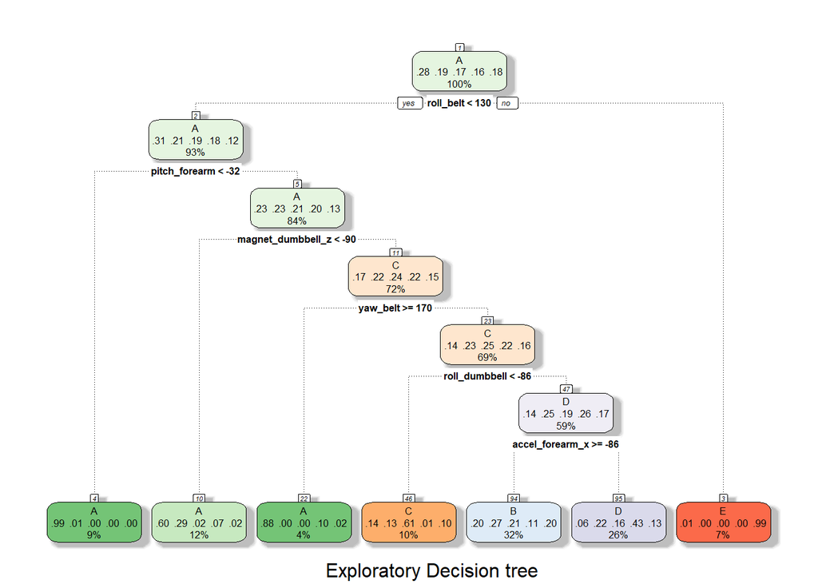

```r
fancyRpartPlot(modFit$finalModel,sub='Exploratory Decision tree')
```

```r
importance <- varImp(modFit)
importantVariables <- rownames(data.frame(importance$importance))[1:15]
importantVariables
```

```
##  [1] "accel_arm_x"       "accel_belt_z"      "accel_dumbbell_x"
##  [4] "accel_dumbbell_y"  "accel_forearm_x"   "magnet_arm_x"
##  [7] "magnet_arm_y"      "magnet_belt_y"     "magnet_dumbbell_y"
## [10] "magnet_dumbbell_z" "pitch_forearm"     "roll_belt"
## [13] "roll_dumbbell"     "roll_forearm"      "yaw_belt"
```

```r
fittedTraining <- select(smallTraining,c(importantVariables,'classe'))
```

### Model Selection

Now that the dataset is smaller (1376 rows x 16 fields), let’s try a computationally expensive model, like random forest, using only these 15 variables as predictors.

```r
modFit2 <- train(classe~.,data=fittedTraining,method='rf')
pred2 <- predict(modFit2,smallTesting)
confusionMatrix(smallTesting$classe,pred2)
```

```
## Confusion Matrix and Statistics
##
##           Reference
## Prediction   A   B   C   D   E
##          A 265   4   3   2   0
##          B  11 166   7   3   0
##          C   0  14 152   1   1
##          D   0   3   6 148   1
##          E   1   1   6   4 165
##
## Overall Statistics
##
##                Accuracy : 0.9295
##                  95% CI : (0.9114, 0.9448)
##     No Information Rate : 0.2873
##     P-Value [Acc > NIR] : < 2e-16
##
##                   Kappa : 0.9108
##  Mcnemar's Test P-Value : 0.01761
##
## Statistics by Class:
##
##                      Class: A Class: B Class: C Class: D Class: E
## Sensitivity            0.9567   0.8830   0.8736   0.9367   0.9880
## Specificity            0.9869   0.9729   0.9797   0.9876   0.9849
## Pos Pred Value         0.9672   0.8877   0.9048   0.9367   0.9322
## Neg Pred Value         0.9826   0.9717   0.9724   0.9876   0.9975
## Prevalence             0.2873   0.1950   0.1805   0.1639   0.1732
## Detection Rate         0.2749   0.1722   0.1577   0.1535   0.1712
## Detection Prevalence   0.2842   0.1940   0.1743   0.1639   0.1836
## Balanced Accuracy      0.9718   0.9280   0.9267   0.9622   0.9865
```

An accuracy of 91.14%-94.48% (at 95% confidence) and a Kappa score of 0.9108 means this is a very strong model!

The Random Forest model works very well on our small training data. We will select this model for our analysis.

So, time to scale it up. Now let’s go back to the full training dataset, trim the fields down to these 15 fields, and run a random forest model.

```r
#Use a smaller amount of variables based on the useful predictors found in our decision tree model
fittedTraining <- select(training,c(importantVariables,'classe'))
#Create a Random forest model
modFit3 <- train(classe~.,data=fittedTraining,method='rf')
```

How well did the model do to predict classe on the training data?

```r
confusionMatrix(training$classe,predict(modFit3,training))
```

```
## Confusion Matrix and Statistics
##
##           Reference
## Prediction    A    B    C    D    E
##          A 3906    0    0    0    0
##          B    0 2658    0    0    0
##          C    0    0 2396    0    0
##          D    0    0    0 2252    0
##          E    0    0    0    0 2525
##
## Overall Statistics
##
##                Accuracy : 1
##                  95% CI : (0.9997, 1)
##     No Information Rate : 0.2843
##     P-Value [Acc > NIR] : < 2.2e-16
##
##                   Kappa : 1
##  Mcnemar's Test P-Value : NA
##
## Statistics by Class:
##
##                      Class: A Class: B Class: C Class: D Class: E
## Sensitivity            1.0000   1.0000   1.0000   1.0000   1.0000
## Specificity            1.0000   1.0000   1.0000   1.0000   1.0000
## Pos Pred Value         1.0000   1.0000   1.0000   1.0000   1.0000
## Neg Pred Value         1.0000   1.0000   1.0000   1.0000   1.0000
## Prevalence             0.2843   0.1935   0.1744   0.1639   0.1838
## Detection Rate         0.2843   0.1935   0.1744   0.1639   0.1838
## Detection Prevalence   0.2843   0.1935   0.1744   0.1639   0.1838
## Balanced Accuracy      1.0000   1.0000   1.0000   1.0000   1.0000
```

### Cross Validation

The training data perfectly predicts the data it was trained on. There is a good chance that this model is overfitted. If so, a cross-validation where we apply to the model to the testing dataset will reflect this. We should expect a lower accuracy and kappa value when we predict using the testing data.

```r
pred3 <- predict(modFit3,testing)
confusionMatrix(testing$classe,pred3)
```

```
## Confusion Matrix and Statistics
##
##           Reference
## Prediction    A    B    C    D    E
##          A 1670    4    0    0    0
##          B    7 1121    8    3    0
##          C    0    7 1017    2    0
##          D    1    1   18  943    1
##          E    0    0    2    4 1076
##
## Overall Statistics
##
##                Accuracy : 0.9901
##                  95% CI : (0.9873, 0.9925)
##     No Information Rate : 0.2851
##     P-Value [Acc > NIR] : < 2.2e-16
##
##                   Kappa : 0.9875
##  Mcnemar's Test P-Value : NA
##
## Statistics by Class:
##
##                      Class: A Class: B Class: C Class: D Class: E
## Sensitivity            0.9952   0.9894   0.9732   0.9905   0.9991
## Specificity            0.9990   0.9962   0.9981   0.9957   0.9988
## Pos Pred Value         0.9976   0.9842   0.9912   0.9782   0.9945
## Neg Pred Value         0.9981   0.9975   0.9942   0.9982   0.9998
## Prevalence             0.2851   0.1925   0.1776   0.1618   0.1830
## Detection Rate         0.2838   0.1905   0.1728   0.1602   0.1828
## Detection Prevalence   0.2845   0.1935   0.1743   0.1638   0.1839
## Balanced Accuracy      0.9971   0.9928   0.9857   0.9931   0.9989
```

### Prediction

Let’s finally use the data in the validation set and predict what classe (type of exercise) each record best reflects.

```r
predVal <- predict(modFit3,validation)
predVal
```

```
##  [1] B A B A A E D B A A B C B A E E A B B B
## Levels: A B C D E
```